[figure not shown]

Messi image found at [The Guardian](https://www.theguardian.com/football/2021/jul/14/lionel-messi-agrees-new-five-year-contract-to-stay-with-barcelona)

# **Analyzing Lionel Messi's Career And Predicting How Many Goals He Will Score in 2022/23**

### A Data Science Analysis

*Jarod French*  
Last updated: May 14th 2022

## Introduction:

Lionel Messi is one of the best soccer players on the planet. There has been a long debate between soccer fans whether the greatest player of all time is Messi, or if it is Cristiano Ronaldo, Pelé, the late Diego Maradona, or others. In this tutorial, we will be using python3 and all of the goals Messi has scored in his career to illustrate the Data Science Pipeline:

1. Data collection/curation + parsing (if necessary)
2. Data management/representation
3. Exploratory data analysis
4. Hypothesis testing
5. Communication of insights attained

We will be utilising this dataset of all of Messi's club soccer goals, found on [Kaggle](https://www.kaggle.com/datasets/azminetoushikwasi/-lionel-messi-all-club-goals?select=data.csv). The dataset includes data such as the season, competition, matchday, venue, date, Messi's team, the opponent, the result, Messi's position, the minute the goal was scored, the score when Messi scored the goal, the type of goal, and who assisted the goal. The dataset was last updated April 23, 2022 so there may be a few missing goals that Messi has scored between then and now.

## Python Libraries Required:

The first step is to import the libraries we will be using to read the data and to create plots as well as perform regression to make predictions.

- Pandas - to format data and utilize data ([API documentation](https://pandas.pydata.org/docs/reference/index.html#api))
- Numpy - to help utilize and store data ([API documentation](https://numpy.org/doc/stable/reference/index.html#reference))
- Matplotlib.pyplot - to help visualize data and label figures ([API documentation](https://matplotlib.org/3.5.0/api/_as_gen/matplotlib.pyplot.html))
- Seaborn - to build plots and graphs in order to visualize data ([API documentation](https://seaborn.pydata.org/api.html))

```python
# Use this line to make plots show automatically instead of using plt.show()
%matplotlib inline
# this line makes the images render at a higher resolution
%config InlineBackend.figure_format = 'retina'
import pandas as pd
# Pandas also extends Numpy so it's a good idea to import numpy
# also because in some cases Numpy is easier to use than pandas and they are compatible.
import numpy as np
import matplotlib.pyplot as plt
import seaborn as sns
# pd, np, plt, and sns are common naming conventions for the respective libraries
# note: plt and sns work well together when plotting, you can use both libraries on the seaborn plots
```

## 1. Data Collection and 2. Data Representation

To start this analysis, we must first import the data. I have it stored in the same folder as this notebook on my machine, but I will link to the repository I have created with the csv if you want to use the data from my [github repository](https://github.com/jarodfrench/jarodfrench.github.io) (labeled messi_data.csv), or the Kaggle page to [download](https://www.kaggle.com/datasets/azminetoushikwasi/-lionel-messi-all-club-goals?select=data.csv) for yourself.

```python
# Utilize Pandas read csv function to read the data into a Pandas Dataframe
messi = pd.read_csv('messi_data.csv')
messi.head()
```

|  | Season | Competition | Matchday | Date | Venue | Club | Opponent | Result | Playing_Position | Minute | At_score | Type | Goal_assist |
| --- | --- | --- | --- | --- | --- | --- | --- | --- | --- | --- | --- | --- | --- |
| 0 | 04/05 | LaLiga | 34 | 5/1/05 | H | FC Barcelona | Albacete Balompie | 2:0 | CF | 90+1 | 2:0 | Left-footed shot | Ronaldinho Gaacho |
| 1 | 05/06 | UEFA Champions League | Group Stage | 11/2/05 | H | FC Barcelona | Panathinaikos Athens | 5:0 | RW | 34 | 3:0 | Left-footed shot | NaN |
| 2 | 05/06 | LaLiga | 13 | 11/27/05 | H | FC Barcelona | Racing Santander | 4:1 | RW | 51 | 2:0 | Left-footed shot | Samuel Etoo |
| 3 | 05/06 | LaLiga | 19 | 1/15/06 | H | FC Barcelona | Athletic Bilbao | 2:1 | RW | 50 | 2:1 | Left-footed shot | Mark van Bommel |
| 4 | 05/06 | LaLiga | 20 | 1/22/06 | H | FC Barcelona | Deportivo Alaves | 2:0 | CF | 82 | 2:0 | Left-footed shot | Ronaldinho Gaacho |

Now that the data is stored in a Pandas DataFrame, we can make sure it is complete and contains everything we need. Let's run the info function.

```python
# Pandas has an info function that gives information about data types and missing values along with the column titles and other information.
messi.info()
```

```
<class 'pandas.core.frame.DataFrame'>
RangeIndex: 681 entries, 0 to 680
Data columns (total 13 columns):
 #   Column            Non-Null Count  Dtype
---  ------            --------------  -----
 0   Season            681 non-null    object
 1   Competition       681 non-null    object
 2   Matchday          681 non-null    object
 3   Date              681 non-null    object
 4   Venue             681 non-null    object
 5   Club              681 non-null    object
 6   Opponent          681 non-null    object
 7   Result            681 non-null    object
 8   Playing_Position  681 non-null    object
 9   Minute            681 non-null    object
 10  At_score          681 non-null    object
 11  Type              680 non-null    object
 12  Goal_assist       472 non-null    object
dtypes: object(13)
memory usage: 69.3+ KB
```

When we run info() on the DataFrame, we get a the number of entries (rows), a list of the columns, the number of non-null values in each column, the data type of the values in each column and the memory usage.

From the number of rows, we can see Messi has scored 681 total club goals thus far in his career. We can also see from the non null values there is 1 missing value in the type of goal column in our DataFrame, and 209 missing goal assists. Since there is only 1 type of goal missing, its reasonable to look it up, therefore collecting the data so lets isolate it so we know what to collect.

```python
# Create a new DataFrame of only rows with missing data: missing_messi
missing_messi = messi[messi.isna().any(axis=1)]
# Locate the row with the missing Type of goal by filtering the dataset with only the rows with NaN values in the Type column.
missing_messi[missing_messi['Type'].isna()]
```

|  | Season | Competition | Matchday | Date | Venue | Club | Opponent | Result | Playing_Position | Minute | At_score | Type | Goal_assist |
| --- | --- | --- | --- | --- | --- | --- | --- | --- | --- | --- | --- | --- | --- |
| 22 | 06/07 | LaLiga | 37 | 6/9/07 | H | FC Barcelona | RCD Espanyol Barcelona | 2:2 | RW | 43 | 1:1 | NaN | Gianluca Zambrotta |

```python
# Change the value of the cell in the DataFrame.
messi['Type'][22] = "Header"
# Confirm that the value was changed.
# run this line without the semi-colon in your analysis so that the output prints.
messi.iloc[22];
```

Now we still have 209 missing values in the assist column, however, that data is Missing Completely at Random, but there are two possible reasons that those 209 goals are missing values. The first reason could be because those goals that Messi scored were unassisted, which is not uncommon in soccer. The other reason is that whoever collected the data might not have been able to find a player who assisted Messi for that goal. This is less likely but either way, we have to leave the missing data alone. This does not really affect our analysis too much, however.

We have already run the info function that gave us information about missing values and the size of the data, and there is another function we can run now.The describe function in pandas gives us several different statistics about our dataset. It includes summary statistics for datasets with more numerical values, however our data has a lot of categorical variables so the function is limited for this dataset.

```python
messi.describe()
```

|  | Season | Competition | Matchday | Date | Venue | Club | Opponent | Result | Playing_Position | Minute | At_score | Type | Goal_assist |
| --- | --- | --- | --- | --- | --- | --- | --- | --- | --- | --- | --- | --- | --- |
| count | 681 | 681 | 681 | 681 | 681 | 681 | 681 | 681 | 681 | 681 | 681 | 681 | 472 |
| unique | 18 | 7 | 48 | 438 | 2 | 2 | 87 | 46 | 9 | 96 | 38 | 12 | 63 |
| top | 11/12 | LaLiga | Group Stage | 3/7/12 | H | FC Barcelona | Sevilla FC | 4:0 | CF | 87 | 1:0 | Left-footed shot | Luis Suarez |
| freq | 73 | 474 | 76 | 5 | 410 | 672 | 38 | 45 | 264 | 13 | 96 | 420 | 48 |

## 3. Exploratory Data Analysis

```
{'Team': array(['FC Barcelona', 'Paris Saint-Germain'], dtype=object), 'Goals': [672, 9]}
```

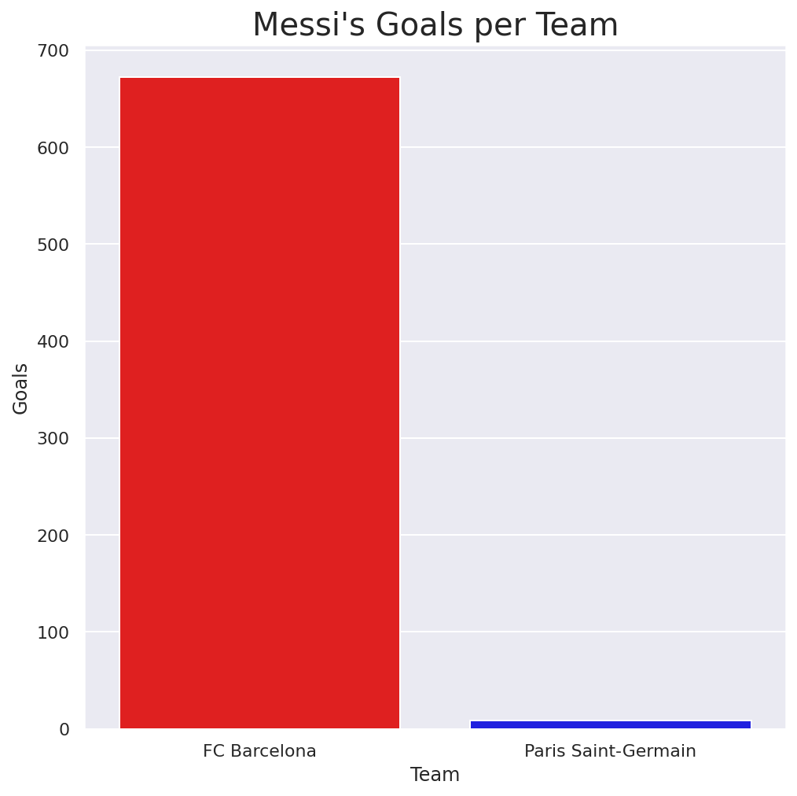

```python
# First calculate how many goals he has scored on each team:
# use this dict to store the number of goals counted to convert it into a DataFrame later.
goals_dict = {}
goals_dict['Team'] = messi['Club'].unique()

# count how many goals he scored for each team using simple counter variables
barca_count = 0
psg_count = 0
for i in messi['Club']:
    if i == "FC Barcelona":
        barca_count += 1
    if i == "Paris Saint-Germain":
        psg_count += 1

# update the dictionary
goals_dict['Goals'] = [barca_count, psg_count]
print(goals_dict)
# it's easier to plot a DataFrame so convert into a DataFrame
goals_df = pd.DataFrame(goals_dict)

# Plot the figure using Seaborn's barplot function
sns.set(rc={'figure.figsize' : (8,8)})
ax = sns.barplot(x=goals_df['Team'], y=goals_df['Goals'], palette=['red','blue']) # I wanted the colors to match the team's jerseys somewhat.
ax.axes.set_title(label="Messi's Goals per Team", fontsize=20);
```

Another very important stat to look at is Messi's goals per season in all competitions. Seaborn has a really nice feature called a countplot that can plot this for us if we just pass in the Season column of our DataFrame.

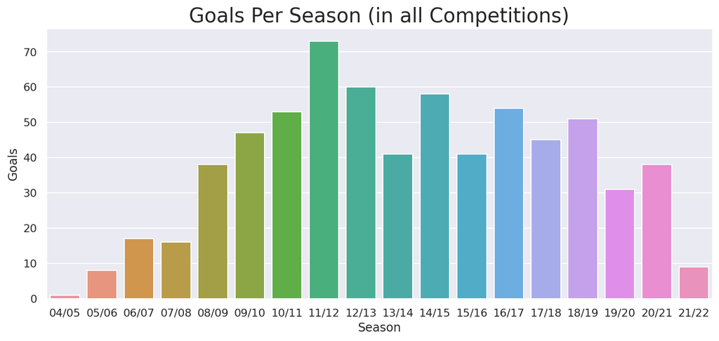

```python
# set the size of the figure
sns.set(rc={'figure.figsize' : (12,5)})
p = sns.countplot(x=messi['Season'], hue_order=messi.groupby('Season'))
# you can use plt or sns to label the plots
plt.ylabel("Goals")
p.axes.set_title("Goals Per Season (in all Competitions)", fontsize=20); # semicolon so there's no extraneous output
```

By looking at this plot, the data is fairly symmetrical, with a few possibe outliers toward the beginning of Messi's career, and another during the current season. We can also see Messi averaged what looks like close to 40 goals per season over the course of 13 seasons, from 08/09 to 20/21. This is an insane average goals per season, because even the late and great fellow Argentinian Diego Maradona only averaged 16 goals per season (115 goals / 7 seasons) in 7 seasons with Napoli (a soccer team in Naples, Italy; Maradona stats credited to [transfermarkt](https://www.transfermarkt.us/diego-maradona/leistungsdaten/spieler/8024) (found in the stats by club table in the middle right side of the page)). Maradona is widely considered one of the top 3 best players of all time. We all know the top 3 players is always personally biased, but it is true many people believe he is a top 3 greatest player of all time. Now lets calculate the actual average goals Messi scored over his whole career and over the 08/09 to 20/21 seasons to get a feeling for how the data is spread.

```python
# obtain a list of each season Messi has played
seasons = messi['Season'].unique()

# make a list of DataFrames, grouped by season
seasons_list = messi.groupby('Season')

# The length of each DataFrame in seasons_list is the number of Goals Messi scored that season
lengths = []
for season in seasons:
    lengths.append(len(seasons_list.get_group(season).index))

# sum the total amount of goals Messi has scored and divide it by the number of total seasons
# number of total seasons is the length of the list of unique seasons in the seasons variable
sum = 0
for season in lengths:
    sum += season
print("Messi scored approximately " + str(sum / len(lengths)) + " goals per season from 04/05 to 21/22.")

# sum the seasons from 04/05 to 20/21 in a similar way
sub_sum = 0
# 4 and 16 are the indices of lengths here that correspond to 04/05 and 20/21 respectively
for i in range(0,len(lengths)):
    if i >= 4 and i <= 16:
        sub_sum += lengths[i]
# divide by 13 because 04/05 to 20/21 is 13 seasons (inclusive)
print("Messi scored approximately " + str(sub_sum / 13) + " goals per season from 08/09 to 20/21.")
```

```
Messi scored approximately 37.833333333333336 goals per season from 04/05 to 21/22.
Messi scored approximately 48.46153846153846 goals per season from 08/09 to 20/21.
```

Of course you can't score a fraction of a goal, so these can be rounded up or down (to suit your own objective) but we will leave them the way they are for accuracy. However, Messi averages almost 40 goals per season which is incredible. He also actually averaged almost 50 goals, more than what we estimated above by looking at the graph, over the seasons between 08/09 and 20/21. Comparing the two averages, we can confirm there is a left skew, which makes sense for a player to be less prolific at the beginning of their career while they are still developing as a player. Usually when a player is this prolific, they stick to their natural position, but lets look at all the positions Messi has played with another plot: goals per position.

We must first check to see what unique positions there are, to make sure that they are all unique.

```python
messi['Playing_Position'].unique()
```

```
array(['CF', 'RW', 'LW', 'SS', 'CF ', 'AM', 'RW ', 'AM ', 'SS '],
      dtype=object)
```

Our dataset happens to have a case where "SS" and "SS " are the same position, and our dataset includes this pattern for several positions. So we will remove the space on the second possibility of SS, CF, RW, and AM so that we only have the unique positions.

```python
messi['Playing_Position'] = messi['Playing_Position'].str.replace('SS ','SS')
messi['Playing_Position'] = messi['Playing_Position'].str.replace('CF ','CF')
messi['Playing_Position'] = messi['Playing_Position'].str.replace('RW ','RW')
messi['Playing_Position'] = messi['Playing_Position'].str.replace('AM ','AM')
messi['Playing_Position'].unique()
```

```
array(['CF', 'RW', 'LW', 'SS', 'AM'], dtype=object)
```

Now we have the five unique positions that Messi has played so we can go ahead and plot.

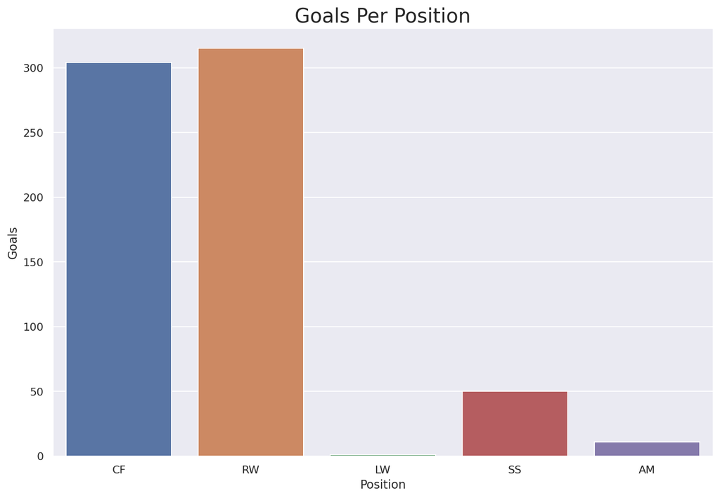

```python
# set the size of the figure
sns.set(rc={'figure.figsize' : (12,8)})
p = sns.countplot(x=messi['Playing_Position'], hue_order=messi.groupby('Competition'))
# you can use plt or sns to label the plots
plt.ylabel("Goals")
plt.xlabel("Position")
p.axes.set_title("Goals Per Position", fontsize=20); # semicolon so there's no extraneous output
```

Messi has scored a plethora of goals as either a Center Forward (CF) or a Right Wing (RW), and several more goals as an Attacking Midfielder (AM), Single Striker (SS), and Left Wing (LW). Most players wouldn't score even 150 goals in their career and here Messi has doubled that total in two different positions, which is very difficult to do. It certainly goes to show just how good of a player he is no matter where he is on the field.

Scoring goals is all well and good, and Messi has a ton of goals, but soccer also has several different competitions that occur all at once over the course of a season. This means it is important to consider consistancy over all competitions as well so let's plot the different competitions Messi has played in to see how consistant he is in his scoring in all competitions.

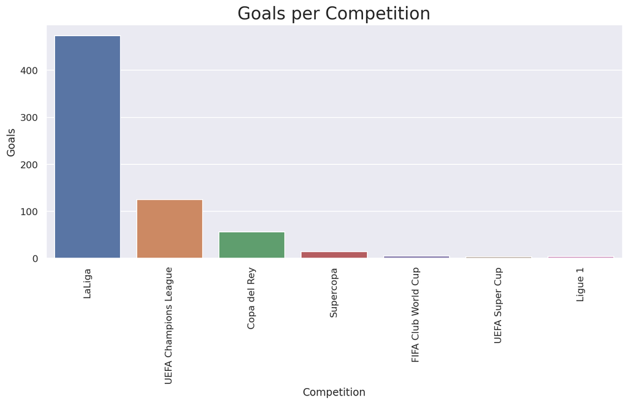

```python
#  change the size of the figure
sns.set(rc={'figure.figsize' : (12,5)})
# the competition labels will overlap if they're horizontal so let's rotate them.
plt.xticks(rotation='vertical')
# Plot the number of competition vs number of goals
# Hue order just changes the colors for each bar.
p = sns.countplot(x=messi['Competition'], hue_order=messi.groupby('Competition'))
p.axes.set_ylabel(ylabel="Goals") # instead of just labelling it 'count'
p.axes.set_title(label="Goals per Competition", fontsize=20); # semicolon so there's no extraneous output
```

The vast amount of La Liga games Messi has played as well as all the goals Messi has scored in La Liga really affects the center of this plot, considering that for leagues like the UEFA Super Cup Messi has only played a few games. This shows a heavy right skew. However, this is the true distribution of Messi's goals beacause players tend to score more when they have more games in a competition. It becomes clear that Messi scored a lot of La Liga goals during his long time at Barcelona.

The next plot to understand the data is actually a bit fun in my opinion. We will plot the number of goals per minute section of a game Messi has scored as a histogram over the course 120 minutes so that we can include the games where Messi scored in overtime.

The first problem we will run into for this plot, is that the minute column in the DataFrame must be cleaned more because some of the goals are labeled as "90+1" or "45+2". For background, this is a byproduct of the clock never stopping in soccer, the referee will just keep track of all of the times that the game is "paused" for injury, goal celebrations, etc. and then add that time on to the end of the half. This is called stoppage time. For example, a normal half of soccer might get to the 45th minute, and then the referee adds on 2 minutes because of game stoppages, giving us the minutes 45+1 and 45+2. These are impossible to plot with integers, so they must be changed. For the purposes of this plot, we are going to consider 45+2 to be the 47th minute, and 90+1 is the 91st minute. The 47th minute is technically the first half still, but since we are not separating by halves, we can just call it the 47th minute.

In order to update these values to be integers, we are going to utilize the python regex library, re. To match the 90+1 values, we group the first set of digits, match the plus sign, and then group the second set of digits. I used [rubular](https://rubular.com/) to help me format the regex, even though that is primarily for regex for programs in the ruby language, regex is itself its own language so I can just use single quotes in re rather than the slashes rubular uses to start and end the regex expression. We will then add the digits together so 90+1 = 91. While we do this we will ensure that all the values are ints, because far above in our info function output, the dtypes were all listed as object (most likely as a string object).

For the histogram, we'll use bins of 15 minute game time intervals, since the game is divided evenly that way.

- re - to use regex to isolate values in strings and other expressions ([API documentation](https://docs.python.org/3/library/re.html))

```python
import re
```

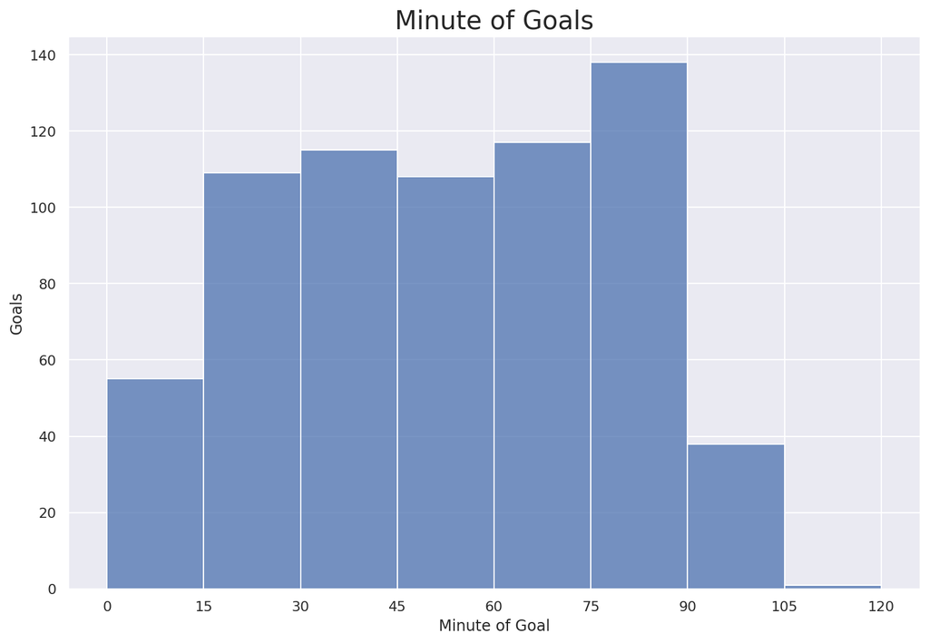

```python
# expression to match and group the integers.
regexp = '(\d{2})\+(\d{1,2})'

# change the values to all integers as well as match the values with '+' and then add them as integers.
for i, row in messi.iterrows():
    match = re.match(regexp, row['Minute'])
    if match:
        messi['Minute'][i] = int(match.group(1)) + int(match.group(2))
    else:
        messi['Minute'][i] = int(messi['Minute'][i])

bins=[0,15,30,45,60,75,90,105,120]
# set the size of the figure
sns.set(rc={'figure.figsize' : (12,8)})
plt.xticks(bins) # Use plt.xticks to label the xticks on a seaborn plot
p = sns.histplot(data=messi,x=messi['Minute'], bins= bins)
# label the plots
plt.ylabel("Goals")
plt.xlabel("Minute of Goal")
p.axes.set_title("Minute of Goals", fontsize=20); # semicolon so there's no extraneous output
```

Obviously, since overtime doesn't happen often, and never happens in league games, the 105 to 120 minute bin only represents overtime and the 10 to 105 minute bin is a combo of the first half of overtime and the goals Messi has scored in second half stoppage time. With that in mind, the low frequency of overtime occurrences leads me to believe that most of the goals in that bin are stoppage time goals. Overall, Messi seems to get better at scoring the longer a normal regulation game goes, with his goals peaking between the 75th and 90th minute. This is not to say that he isn't consistantly scoring between the 15th and 75th minute, however. This histogram is slightly skewed left since the peak is toward the right, although it is very close to symmetrical, meaning Messi is pretty much a dangerous goalscorer no matter what minute of the match it is.

Goals can also be scored in a variety of ways, but Messi scores a large variety of goals. While players tend to score with left or right footed shots or headers, Messi scores with many more types of goal. This is important to see that Messi is not just what some people call a "one trick pony".

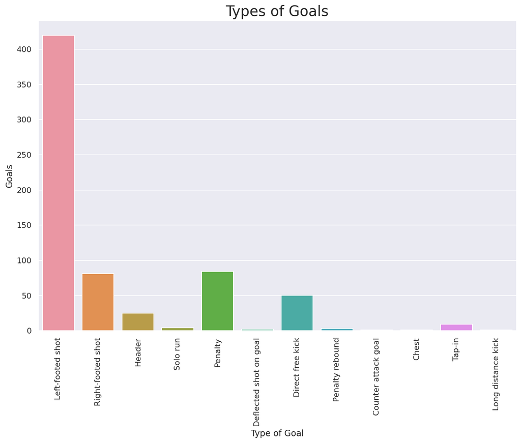

```python
# set the size of the figure
sns.set(rc={'figure.figsize' : (12,8)})
plt.xticks(rotation='vertical')
p = sns.countplot(x=messi['Type'], hue_order=messi.groupby('Competition'))
# you can use plt or sns to label the plots
plt.ylabel("Goals")
plt.xlabel("Type of Goal")
p.axes.set_title("Types of Goals", fontsize=20); # semicolon so there's no extraneous output
```

One of the things that stands out in this plot, is the number of Direct Free Kick goals Messi has scored. Most players would be lucky to even take a free kick, let alone score it, and Messi has scored 50 of them. That is an incredible total, and deserves to be recognized. We have also learned that Messi's left foot is lethal on a soccer field, although soccer fans will have already known that. More than 400 goals with his left foot is unreal.

Let's revisit the goals per competition. It is pretty obvious how many goals Messi has scored for Barcelona since La Liga, Copa del Rey and most of Messi's UEFA Champions League goals were scored while he was at Barcelona. Let's analyze Messi's goals per game ratios in three different competitions: La Liga, Ligue 1, and the UEFA Champions League. Standardizing the goals per game will show us how prolific Messi is in each competition. To do that, we will write a function that cuts the dataset into several datasets.

```python
# dataset = data to use, group_names are the names of the chunks,
# column_name is the name of the column to sort by to get the chunks
def cut_dataframe_into_chunks(dataset, group_names, column_name):
    # with the data cut into the number of bins, append each bin into a list of datasets based on the groups above
    tables = []
    for curr in group_names:
        tables.append(dataset.groupby(column_name).get_group(curr))
    return tables

group_names = messi['Competition'].unique()
grouped_messi = cut_dataframe_into_chunks(dataset=messi, group_names=group_names, column_name='Competition')
```

Now we have a list of DataFrames, one for the goals Messi has scored in each competition. We are in need of the total amount of games Messi has played in each competition in order to do this. Since our dataset only has the games in which Messi scores, it does not include games in which he does not score, so we will be relying on another dataset. This one is from FBref, which allows people to use their data for free as long as we mention that we got the data from them, and only if we are not creating something to rival FBref. Thank you FBref! (data found at this [link](https://fbref.com/en/players/d70ce98e/all_comps/Lionel-Messi-Stats---All-Competitions)). They are owned by Sports Reference which has other sites with many other sports' stats.

```python
# read the csv file using pandas
playing_time = pd.read_csv('Messi_playing_time.csv')
# run the next line in this comment to see the list of columns in order to figure out which columns to drop.
# print(playing_time.columns)
# axis = 1 tells pandas to drop columns, not rows.
playing_time = playing_time.drop(['Age', 'Country', 'Starts', 'Min', '90s', 'Gls', 'Ast', 'G-PK', 'PK', 'PKatt', 'CrdY', 'CrdR', 'Gls.1',
       'Ast.1', 'G+A', 'G-PK.1', 'G+A-PK', 'xG', 'npxG', 'xA', 'npxG+xA',
       'xG.1', 'xA.1', 'xG+xA', 'npxG.1', 'npxG+xA.1', 'Matches'], axis=1)

# clean the strings in the competition column by replacein the parts that we don't want with ""
playing_time['Comp'] = playing_time['Comp'].str.replace('1. ','')
playing_time['Comp'] = playing_time['Comp'].str.replace('Champions Lg', 'UEFA Champions League')
playing_time['Comp'] = playing_time['Comp'].str.replace('La Liga', 'LaLiga')
playing_time['Comp'] = playing_time['Comp'].str.replace('Super Cup', 'UEFA Super Cup')
playing_time['Comp'] = playing_time['Comp'].str.replace('Supercopa de España', 'Supercopa')

# tail shows a more diverse number of competitons to check our replacement work
playing_time.tail(6)
```

|  | Season | Squad | Comp | MP |
| --- | --- | --- | --- | --- |
| 45 | 2020-2021 | Barcelona | Copa del Rey | 5 |
| 46 | 2020-2021 | Barcelona | LaLiga | 35 |
| 47 | 2020-2021 | Barcelona | Supercopa | 1 |
| 48 | 2021-2022 | Paris S-G | UEFA Champions League | 7 |
| 49 | 2021-2022 | Paris S-G | Coupe de France | 1 |
| 50 | 2021-2022 | Paris S-G | Ligue 1 | 24 |

Now that we have a clean dataset, we still need to calculate the number of total games Messi has played per competition, instead of the per competition per year that we have in this dataset.

```python
# make a dictionary for all the matches played in each competition
matches_dict = {}

# populate it with the competitions as keys and values set to 0
for label in playing_time['Comp'].unique():
    matches_dict[label] = 0

# update the values to be the matches played count
for i in playing_time.index:
    matches_dict[str(playing_time['Comp'][i])] += playing_time['MP'][i]

# delete the keys we don't need from the dict.
del matches_dict['Coupe de France']
del matches_dict['Copa del Rey']
del matches_dict['UEFA Super Cup']
del matches_dict['Supercopa']
print("Messi has played these games: " + str(matches_dict))
```

```
Messi has played these games: {'UEFA Champions League': 156, 'LaLiga': 519, 'Ligue 1': 24}
```

Now we can calculate the goals per game in each competition. This is done by dividing number of goals in the competition by the number of games played in the competition.

```python
# looking at the indices of the grouped_messi list, we can find the dataframe that includes each competition we want.
laliga_goals = grouped_messi[0]['Date'].count()
ucl_goals = grouped_messi[1]['Date'].count()
ligue1_goals = grouped_messi[6]['Date'].count()

# use matches_dict for number of games
# calculate goals per game by dividing goals in the competition by number of games played in the competition
laliga_gpg = laliga_goals / matches_dict['LaLiga']
ucl_gpg = ucl_goals / matches_dict['UEFA Champions League']
ligue1_gpg = ligue1_goals / matches_dict['Ligue 1']

print("Messi has scored " + str(laliga_gpg) + " goals per game in " + str(matches_dict['LaLiga']) + " games in La Liga.")
print("Messi has scored " + str(ucl_gpg) + " goals per game in " + str(matches_dict['UEFA Champions League']) + " games in the UEFA Champions League.")
print("Messi has scored " + str(ligue1_gpg) + " goals per game in " + str(matches_dict['Ligue 1']) + " games in Ligue 1.")
```

```
Messi has scored 0.9132947976878613 goals per game in 519 games in La Liga.
Messi has scored 0.8012820512820513 goals per game in 156 games in the UEFA Champions League.
Messi has scored 0.16666666666666666 goals per game in 24 games in Ligue 1.
```

Messi has scored almost 1 goal per game in la liga, which is incredible to average almost a goal per game over 519 games. Most players would be lucky to average a goal a game for a 3 game stretch, but Messi did it for more then 500 games. The Champions League average is also impressive as Messi has scored 0.8 goals per game. The UEFA Champions League is a competition where all of the best teams in Europe, which are also the best teams in the world play against each other. So Messi averages 0.8 goals per game against the best teams in the world. This is a very impressive feat. However, on the other hand, he only averages 0.166666 goals per game in Ligue 1 in France for Paris Saint-Germain. This is definitely disappointing, even though Messi has only played 24 games in Ligue 1. As an aside (that is biased on personal opinion), Messi leaving Barcelona for Paris after 17 years, one would expect there would be a year to get used to a new league, and I would hope he does better in the 2022/23 season.

There is also the fact that Messi has played for Barcelona and Paris Saint-Germain(PSG) in the champions League, so we will take a look at how he has performed in the Champions League with Barcelona and PSG separately and compare them.

```python
# get dataframes of the goals Messi scored in the champions league on each team.
barca_ucl_goals = grouped_messi[1][grouped_messi[1]['Club'] == "FC Barcelona"]
psg_ucl_goals = grouped_messi[1][grouped_messi[1]['Club'] == "Paris Saint-Germain"]
# count the values in the date column to get the total number of goals he scored.
# you can use any column, since each row corresponds to a goal, date is just an arbitrary selection
barca_goals = barca_ucl_goals['Date'].count()
psg_goals = psg_ucl_goals['Date'].count()

# obtain the number of games Messi played in the champions league on each team.
ucl_games_df = playing_time[playing_time['Comp'] == "UEFA Champions League"]
barca_ucl_games = ucl_games_df[ucl_games_df['Squad'] == "Barcelona"]['MP'].sum()
psg_ucl_games = ucl_games_df[ucl_games_df['Squad'] == "Paris S-G"]['MP'].sum()

# calculate Messi's goals per game on each team.
barca_ucl_gpg = barca_goals / barca_ucl_games
psg_ucl_gpg = psg_goals / psg_ucl_games

print("Messi has scored " + str(barca_ucl_gpg) + " goals per game in the UEFA Champions League for FC Barcelona.")
print("Messi has scored " + str(psg_ucl_gpg) + " goals per game in the UEFA Champions League for Paris Saint-Germain.")
```

```
Messi has scored 0.8053691275167785 goals per game in the UEFA Champions League for FC Barcelona.
Messi has scored 0.7142857142857143 goals per game in the UEFA Champions League for Paris Saint-Germain.
```

We can see that Messi has actually kept up his ridiculously good average goals per game in the Champions League while he is on PSG. This is very impressive especially considering his disappointing Ligue 1 tally.

## 4. Hypothesis Testing

Now we want to predict how many goals messi will score in the future. We must revisit Messi's goals per season statistics. He is already 34, but he should have at least one more year, but hopefully a few more years of playing soccer left in his career. Here we are looking at the impact the season and therefore Messi's age has on his goal total for the season.

**Our Null Hypothesis is that the Season does not affect the goal total.**

To do this regression, we will need to import the statsmodels and SciKit Learn libraries.

- Statsmodels api - gives us a least squares regression ([API documentation](https://www.statsmodels.org/stable/api.html))
- Scikit Learn - To do polynomial regression analysis ([API documentation](https://scikit-learn.org/stable/supervised_learning.html#supervised-learning))
  - Sklearn.linear_model is for performing regression analysis and plotting it.
  - Sklearn.preprocessing we will use for getting polynomial features since we are actually doing polynomial regression since the curve we will fit will be a 2nd order polynimial

```python
from statsmodels import api as sm
from sklearn.linear_model import LinearRegression
from sklearn.preprocessing import PolynomialFeatures;
```

We do the statsmodels regression first, using least squares.

```python
# calculate goals per season list
# Change seasons to just the beginning year, to form a sort of timeline.
for i in range(0, len(seasons)):
    seasons[i] = seasons[i].split('/')
    seasons[i] = '20' + seasons[i][0]

# first get a DataFrame with just the goals and seasons.
goals_per_year_df = pd.DataFrame()
goals_per_year_df['Season'] = seasons
goals_per_year_df['Goals'] = lengths
goals_per_year_df['Season'] = goals_per_year_df.Season.astype(int)

# our x and y values for the regression
x = goals_per_year_df['Season']
y = goals_per_year_df['Goals']
```

We will use the season as our x and the number of goals as our y to do the regression. With statsmodels, you must add the constant (x) manually.

```python
# add constant
sm_x = sm.add_constant(x)

OLS_model = sm.OLS(y,x).fit()
OLS_model.summary()
```

OLS Regression Results

| Dep. Variable: | Goals | R-squared (uncentered): | 0.787 |
| --- | --- | --- | --- |
| Model: | OLS | Adj. R-squared (uncentered): | 0.775 |
| Method: | Least Squares | F-statistic: | 62.90 |
| Date: | Sun, 15 May 2022 | Prob (F-statistic): | 4.11e-07 |
| Time: | 20:42:26 | Log-Likelihood: | -79.171 |
| No. Observations: | 18 | AIC: | 160.3 |
| Df Residuals: | 17 | BIC: | 161.2 |
| Df Model: | 1 |  |  |
| Covariance Type: | nonrobust |  |  |

|  | coef | std err | t | P>\|t\| | [0.025 | 0.975] |
| --- | --- | --- | --- | --- | --- | --- |
| Season | 0.0188 | 0.002 | 7.931 | 0.000 | 0.014 | 0.024 |

| Omnibus: | 0.973 | Durbin-Watson: | 0.548 |
| --- | --- | --- | --- |
| Prob(Omnibus): | 0.615 | Jarque-Bera (JB): | 0.872 |
| Skew: | -0.332 | Prob(JB): | 0.646 |
| Kurtosis: | 2.150 | Cond. No. | 1.00 |

Notes:  
[1] R² is computed without centering (uncentered) since the model does not contain a constant.  
[2] Standard Errors assume that the covariance matrix of the errors is correctly specified.

Therefore, we can **reject the null Hypothesis** that the season does not have any affect on how many goals Messi scores.

OLS fit our data for us, but if you take a look back at our goals per season graph, we can see the data is parabolic which is a 2nd order polynomial and not linear so we must use polynomial fitting.

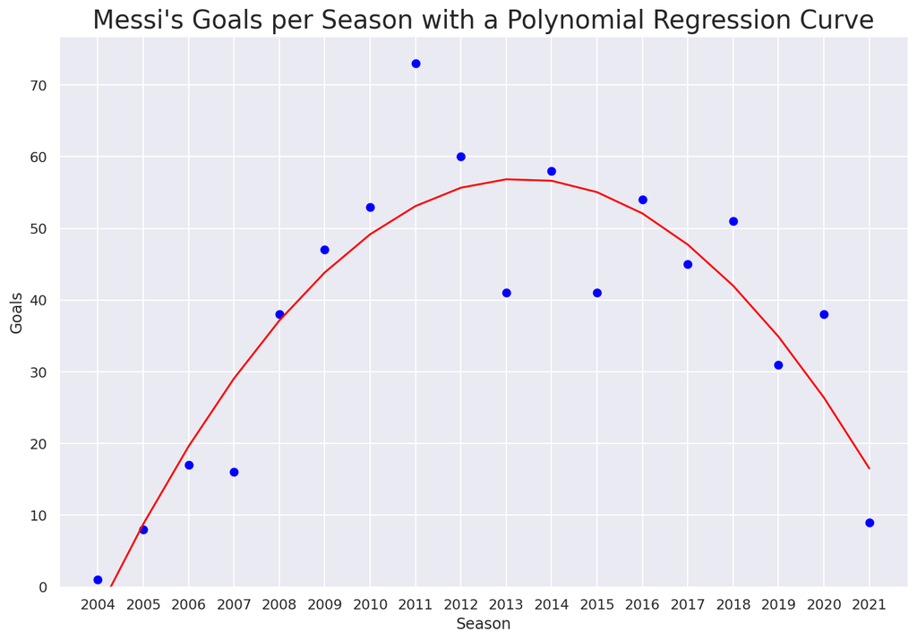

```python
# we must first reshape the season array because sklearn likes it a certain way.
X = goals_per_year_df['Season'].to_numpy().reshape(-1,1)

# # do the regression
# lin = LinearRegression()
# lin.fit(X,y)

poly = PolynomialFeatures(degree=2)
X_poly = poly.fit_transform(X)

poly.fit(X_poly, y)
lin2 = LinearRegression()
lin2.fit(X_poly,y)
plt.figure(figsize=(12,8))
plt.scatter(x,y, color='blue')
plt.plot(X, lin2.predict(poly.fit_transform(X)), color='red')
plt.ylim(ymin=0)
plt.ylabel("Goals")
plt.xlabel("Season")
plt.title("Messi's Goals per Season with a Polynomial Regression Curve", fontsize=20)
plt.xticks(ticks=goals_per_year_df['Season']);
```

In accordance with our R-squared value, the model does not overfit the data, rather it follows the trend as it was designed to do. With this however we can plug in future years in order to predict Messi's future season goal totals. Let's predict how many goals Messi will score in 2022/23. Sklearn uses an array transform to do this so we will plug in the 2022 value as an array.

```python
pred = 2022
predarr = [[pred]]
lin2.predict(poly.fit_transform(predarr))
```

```
array([5.26960783])
```

The array that was printed contians the goal total the model predicted Messi will score in the 2022/23 season. This is quite a measly total, but the data says that that's all he will score if he plays the same as he has been for the past few years, this past year especially. If we follow the curve, we can see where the value of roughly 5.27 goals comes from.

## 5. Conclusions and Insights Attained

Throughout this analysis, we have seen Messi's goals in a number of different ways and ended up predicting his goal total for the 2022/2023 season in all competitions. Messi has scored a total of 681 goals across several competitions at the club soccer level, averaging 37.8 goals per year over his entire career. He has scored in a variety of ways, with his left foot being incredibly accurate and lethal, as well as scoring over a large range of minutes in a match, while playing five different positions in his career. Messi also averaged almost a goal per game in La Liga and the UEFA Champions League in his time at FC Barcelona as well as averaging 0.7 goals per game in the Champions League in his short time at PSG.

From all of these stats, we can conclude that Messi is one of the greatest players of all time, if not the single greatest player. While this is a very opinionated and biased topic, the data proves Messi's accomplishments are absolutely earned. Even though we predicted he will score only 5 goals next season in 2022/2023, soccer fans around the world hope for a resurgence from Messi to return to his Barcelona form and score 40 goals per season again.

List of helpful resources:

Links to find awesome datasets:

- [github](https://github.com/awesomedata/awesome-public-datasets#sports)
- [kaggle](https://www.kaggle.com/)
- [data.gov](https://data.gov/)
- [Maryland Open Data](https://opendata.maryland.gov/)
- [USA COVID Data](https://datascience.nih.gov/covid-19-open-access-resources)

Links in case the in text links don't work:

- Messi image at top of page website - https://www.theguardian.com/football/2021/jul/14/lionel-messi-agrees-new-five-year-contract-to-stay-with-barcelona
- Messi dataset from Kaggle - https://www.kaggle.com/datasets/azminetoushikwasi/-lionel-messi-all-club-goals?select=data.csv
- Pandas API - https://pandas.pydata.org/docs/reference/index.html#api
- Numpy API - https://numpy.org/doc/stable/reference/index.html#reference
- Matplotlib API - https://matplotlib.org/3.5.0/api/_as_gen/matplotlib.pyplot.html
- Seaborn API - https://seaborn.pydata.org/api.html
- My repository with both datasets labeled messi_data.csv(kaggle) and Messi_playing_time.csv(FBref) - https://github.com/jarodfrench/jarodfrench.github.io
- Youtube Video of Missing type of goal - https://www.youtube.com/watch?v=7VZnGczPX-U
- Maradona Information - https://www.transfermarkt.us/diego-maradona/leistungsdaten/spieler/8024
- Rubular - https://rubular.com/
- re API - https://docs.python.org/3/library/re.html
- FBref Dataset - https://fbref.com/en/players/d70ce98e/all_comps/Lionel-Messi-Stats---All-Competitions
- Statsmodels API - https://www.statsmodels.org/stable/api.html
- SciKit Learn API - https://scikit-learn.org/stable/supervised_learning.html#supervised-learning
- Datasets
  - github https://github.com/awesomedata/awesome-public-datasets#sports
  - kaggle https://www.kaggle.com/
  - data.gov https://data.gov/
  - Maryland Open Data https://opendata.maryland.gov/
  - USA COVID data https://datascience.nih.gov/covid-19-open-access-resources
- Helpful Links
  - missing data(1) https://note.nkmk.me/en/python-pandas-nan-extract/#:~:text=source%3A%20pandas_nan_extract.py-,Extract%20rows%2Fcolumns%20with%20missing%20values%20in%20specific%20columns%2Frows,a%20missing%20value%20or%20not.&text=isnull()%20is%20an%20alias,whose%20usage%20is%20the%20same.
  - missing data(2) https://www.mastersindatascience.org/learning/how-to-deal-with-missing-data/#:~:text=When%20dealing%20with%20missing%20data,of%20missing%20data%20is%20low.
  - missing data(3) https://stefvanbuuren.name/fimd/sec-MCAR.html
  - seaborn API https://seaborn.pydata.org/index.html
  - seaborn countplot api https://seaborn.pydata.org/generated/seaborn.countplot.html
  - Messi wikipedia https://en.wikipedia.org/wiki/Lionel_Messi#:~:text=Born%20and%20raised%20in%20central,aged%2017%20in%20October%202004.
  - Messi stats (FBref) https://fbref.com/en/players/d70ce98e/Lionel-Messi
  - Basic Markdown syntax https://www.markdownguide.org/basic-syntax/
  - Matplotlib.text https://matplotlib.org/3.5.0/api/text_api.html#matplotlib.text.Text
  - regression models https://www.analyticsvidhya.com/blog/2022/01/different-types-of-regression-models/
  - numpy.polyfit https://blog.finxter.com/np-polyfit/
  - Python string split method https://www.w3schools.com/python/ref_string_split.asp
  - summing columns in Pandas https://www.statology.org/pandas-sum-column-with-condition/

Works Cited:

Romano, Fabrizio. “Barcelona Agree Five-Year Messi Deal and in Talks to Swap Griezmann for Saúl.” The Guardian,  
Guardian News and Media, 14 July 2021, https://www.theguardian.com/football/2021/jul/14/lionel-messi-agrees-new-five-year-contract-to-stay-with-barcelona.

La, Liga. (2007-06-09) La Liga (2006-2007) - Barcelona 2-2 Espanyol (1-1 Messi). YouTube, YouTube, 6 Jan. 2011, https://www.youtube.com/watch?v=7VZnGczPX-U.  
Accessed 14 May 2022.